# Practical Machine Learning - Assignment

Submitted by Anne Bricis

## Executive Summary

A study was undertaken on a set of measurements recorded during an exercise routine. The objective of the study was to see if the measurements taken could be used to predict the manner in which the exercise had been performed.

## Data preparation

The dataset contains measurements for 6 individuals who had fitted devices on the arm, forearm, belt and dumbbell. The measurements were captured while the individual performed a set of 10 repetitions of an arm curl. The arm curl was performed in 5 different ways: A=correct method, B=elbow to front, C=lift dumbbell halfway, D=lower dumbbell halfway and E=hips to front.

After downloading, the training dataset was analysed (Appendix 1). This contained 160 variables (including the outcome), a number of which had a majority of missing values A subset of the data set was created using only the columns that were considered relevant, ie excluding columns with missing values as well as date columns. The reduced data set contains only 54 variables (including the outcome) which was considered to be more manageable. This reduced set was further split into two, so that local training and testing sets could be applied.

## Model selection

A number of models were developed and analysed.

### Model 1 - Basic reduced variable model

First a model was fitted that used all the variables in the reduced data set as presented (Appendix 2). However this resulted in a poor model which did not even provide for the outcome “D”.

### Model 2 - Preprocessing with principal components analysis

Principal components analysis was then applied over all the variables in the reduced set except the user and outcome (Appendix 3) and this produced better results in that outcome “D” was considered, but the error rate was very high in that over half of the outcomes on the training data set were predicted incorrectly.

Plotting the results of the PCA however identified interesting patterns in the data. When plotted by user, there were four distinct groups with a single user in each, plus a fifth group which overlapped two users. When plotted by outcome, it was very hard to distinguish any difference between the correct method and any of the “incorrect” ones.

## Reference

Velloso, E.; Bulling, A.; Gellersen, H.; Ugulino, W.; Fuks, H. Qualitative Activity Recognition of Weight Lifting Exercises. Proceedings of 4th International Conference in Cooperation with SIGCHI (Augmented Human ’13) . Stuttgart, Germany: ACM SIGCHI, 2013.

## Appendices

### Appendix 1 - Data source

The data files were downloaded from the corresponding Groupware website (http://groupware.les.inf.puc-rio.br/har) as the “Weight Lifting Exercise Dataset”. The training and test data were downloaded using the following r commands:

```r
##train<-download.file("https://d396qusza40orc.cloudfront.net/predmachlearn/pml-training.csv", "train.csv")
##test<-download.file("https://d396qusza40orc.cloudfront.net/predmachlearn/pml-testing.csv", "test.csv")
```

The training data file was reduced to remove superfluous variables (dates, mainly missing values) and further split into two for training and testing.

```r
trainAll<-read.csv("train.csv")
testAll<-read.csv("test.csv")
trainSmall<-trainAll[,-c(1,3:7,12:36,50:59,69:83,87:101, 103:112,125:139,141:150)]
names(trainSmall)
```

```
##  [1] "user_name"            "roll_belt"            "pitch_belt"
##  [4] "yaw_belt"             "total_accel_belt"     "gyros_belt_x"
##  [7] "gyros_belt_y"         "gyros_belt_z"         "accel_belt_x"
## [10] "accel_belt_y"         "accel_belt_z"         "magnet_belt_x"
## [13] "magnet_belt_y"        "magnet_belt_z"        "roll_arm"
## [16] "pitch_arm"            "yaw_arm"              "total_accel_arm"
## [19] "gyros_arm_x"          "gyros_arm_y"          "gyros_arm_z"
## [22] "accel_arm_x"          "accel_arm_y"          "accel_arm_z"
## [25] "magnet_arm_x"         "magnet_arm_y"         "magnet_arm_z"
## [28] "roll_dumbbell"        "pitch_dumbbell"       "yaw_dumbbell"
## [31] "total_accel_dumbbell" "gyros_dumbbell_x"     "gyros_dumbbell_y"
## [34] "gyros_dumbbell_z"     "accel_dumbbell_x"     "accel_dumbbell_y"
## [37] "accel_dumbbell_z"     "magnet_dumbbell_x"    "magnet_dumbbell_y"
## [40] "magnet_dumbbell_z"    "roll_forearm"         "pitch_forearm"
## [43] "yaw_forearm"          "total_accel_forearm"  "gyros_forearm_x"
## [46] "gyros_forearm_y"      "gyros_forearm_z"      "accel_forearm_x"
## [49] "accel_forearm_y"      "accel_forearm_z"      "magnet_forearm_x"
## [52] "magnet_forearm_y"     "magnet_forearm_z"     "classe"
```

```r
library(caret)
inTrain<-createDataPartition(y=trainSmall$classe, p=0.75, list=FALSE)
train<-trainSmall[inTrain,]
test<-trainSmall[-inTrain,]
```

### Appendix 2 - Model 1 analysis - reduce data set

```r
modFitRed<-train(classe~.,method="rpart",data=train)
print(modFitRed$finalModel)
```

```
## n= 14718
##
## node), split, n, loss, yval, (yprob)
##       * denotes terminal node
##
##  1) root 14718 10533 A (0.28 0.19 0.17 0.16 0.18)
##    2) roll_belt< 130.5 13479  9305 A (0.31 0.21 0.19 0.18 0.11)
##      4) pitch_forearm< -33.95 1200     9 A (0.99 0.0075 0 0 0) *
##      5) pitch_forearm>=-33.95 12279  9296 A (0.24 0.23 0.21 0.2 0.12)
##       10) magnet_dumbbell_y< 439.5 10376  7454 A (0.28 0.18 0.24 0.19 0.11)
##         20) roll_forearm< 122.5 6431  3825 A (0.41 0.18 0.19 0.17 0.06) *
##         21) roll_forearm>=122.5 3945  2654 C (0.08 0.18 0.33 0.23 0.18) *
##       11) magnet_dumbbell_y>=439.5 1903   944 B (0.032 0.5 0.038 0.23 0.2) *
##    3) roll_belt>=130.5 1239    11 E (0.0089 0 0 0 0.99) *
```

```r
confusionMatrix(train$classe, predict(modFitRed,train))
```

```
## Confusion Matrix and Statistics
##
##           Reference
## Prediction    A    B    C    D    E
##          A 3797   61  316    0   11
##          B 1175  959  714    0    0
##          C 1203   73 1291    0    0
##          D 1069  436  907    0    0
##          E  387  374  717    0 1228
##
## Overall Statistics
##
##                Accuracy : 0.4943
##                  95% CI : (0.4862, 0.5024)
##     No Information Rate : 0.5185
##     P-Value [Acc > NIR] : 1
##
##                   Kappa : 0.3392
##  Mcnemar's Test P-Value : NA
##
## Statistics by Class:
##
##                      Class: A Class: B Class: C Class: D Class: E
## Sensitivity            0.4976  0.50394  0.32725       NA  0.99112
## Specificity            0.9453  0.85259  0.88156   0.8361  0.89035
## Pos Pred Value         0.9073  0.33673  0.50292       NA  0.45381
## Neg Pred Value         0.6360  0.92047  0.78158       NA  0.99908
## Prevalence             0.5185  0.12930  0.26804   0.0000  0.08418
## Detection Rate         0.2580  0.06516  0.08772   0.0000  0.08344
## Detection Prevalence   0.2843  0.19350  0.17441   0.1639  0.18386
## Balanced Accuracy      0.7214  0.67827  0.60440       NA  0.94073
```

### Appendix 3 - Model 2 analysis - PCA

```r
preProc<-preProcess(train[-c(1,54)], method="pca",pcaComp=2)
trainPCA<-predict(preProc, train[-c(1,54)])
modFitPCA<-train(train$classe~.,method="rpart",data=trainPCA)
print(modFitPCA$finalModel)
```

```
## n= 14718
##
## node), split, n, loss, yval, (yprob)
##       * denotes terminal node
##
##    1) root 14718 10533 A (0.28 0.19 0.17 0.16 0.18)
##      2) PC1>=5.018659 674   108 A (0.84 0.028 0.03 0 0.1) *
##      3) PC1< 5.018659 14044 10425 A (0.26 0.2 0.18 0.17 0.19)
##        6) PC1>=-3.986803 13073  9619 A (0.26 0.21 0.19 0.16 0.17)
##         12) PC1>=3.668111 1201   832 C (0.29 0.21 0.31 0.05 0.15)
##           24) PC2>=1.321372 237    90 A (0.62 0.13 0.1 0 0.15) *
##           25) PC2< 1.321372 964   619 C (0.21 0.23 0.36 0.062 0.15) *
##         13) PC1< 3.668111 11872  8765 A (0.26 0.21 0.18 0.17 0.18)
##           26) PC1>=2.576393 1302   848 A (0.35 0.13 0.12 0.3 0.11)
##             52) PC2< -0.05175005 617   276 A (0.55 0.13 0.11 0.13 0.076) *
##             53) PC2>=-0.05175005 685   380 D (0.16 0.13 0.13 0.45 0.14) *
##           27) PC1< 2.576393 10570  7917 A (0.25 0.22 0.19 0.16 0.19)
##             54) PC2>=4.767537 1553  1017 A (0.35 0.13 0.24 0.17 0.11) *
##             55) PC2< 4.767537 9017  6900 A (0.23 0.23 0.18 0.16 0.2)
##              110) PC2< 0.9039571 7195  5424 A (0.25 0.22 0.19 0.17 0.17)
##                220) PC2>=-1.291158 2553  1705 A (0.33 0.21 0.14 0.2 0.11)
##                  440) PC2< 0.3049126 1472   815 A (0.45 0.24 0.12 0.11 0.075) *
##                  441) PC2>=0.3049126 1081   725 D (0.18 0.16 0.17 0.33 0.16) *
##                221) PC2< -1.291158 4642  3557 B (0.2 0.23 0.22 0.15 0.2)
##                  442) PC1< -0.6884134 1163   803 A (0.31 0.21 0.31 0.055 0.12) *
##                  443) PC1>=-0.6884134 3479  2638 B (0.16 0.24 0.19 0.18 0.22)
##                    886) PC2< -3.355775 268   105 B (0.06 0.61 0.0075 0.29 0.03) *
##                    887) PC2>=-3.355775 3211  2448 E (0.17 0.21 0.21 0.17 0.24)
##                     1774) PC2< -2.408853 1412   985 E (0.2 0.24 0.14 0.12 0.3) *
##                     1775) PC2>=-2.408853 1799  1337 C (0.15 0.19 0.26 0.22 0.19)
##                       3550) PC1>=1.326911 1040   674 C (0.18 0.19 0.35 0.15 0.13) *
##                       3551) PC1< 1.326911 759   528 D (0.11 0.2 0.13 0.3 0.26) *
##              111) PC2>=0.9039571 1822  1229 E (0.19 0.25 0.13 0.1 0.33)
##                222) PC1>=-2.126412 1344   939 B (0.25 0.3 0.15 0.091 0.21)
##                  444) PC1>=-0.6274664 388   198 A (0.49 0.16 0.11 0.026 0.21) *
##                  445) PC1< -0.6274664 956   612 B (0.15 0.36 0.16 0.12 0.21) *
##                223) PC1< -2.126412 478   171 E (0.021 0.098 0.1 0.14 0.64) *
##        7) PC1< -3.986803 971   610 E (0.17 0.15 0.021 0.29 0.37) *
```

```r
confusionMatrix(train$classe, predict(modFitPCA,trainPCA))
```

```
## Confusion Matrix and Statistics
##
##           Reference
## Prediction    A    B    C    D    E
##          A 2797  162  382  386  458
##          B  996  507  410  415  520
##          C 1062  153  711  372  269
##          D  590  191  220  892  519
##          E  659  211  281  460 1095
##
## Overall Statistics
##
##                Accuracy : 0.4078
##                  95% CI : (0.3998, 0.4158)
##     No Information Rate : 0.4147
##     P-Value [Acc > NIR] : 0.9569
##
##                   Kappa : 0.2392
##  Mcnemar's Test P-Value : <2e-16
##
## Statistics by Class:
##
##                      Class: A Class: B Class: C Class: D Class: E
## Sensitivity            0.4582  0.41422  0.35479  0.35327   0.3827
## Specificity            0.8389  0.82652  0.85402  0.87534   0.8641
## Pos Pred Value         0.6683  0.17802  0.27698  0.36982   0.4047
## Neg Pred Value         0.6860  0.93960  0.89359  0.86730   0.8530
## Prevalence             0.4147  0.08316  0.13616  0.17156   0.1944
## Detection Rate         0.1900  0.03445  0.04831  0.06061   0.0744
## Detection Prevalence   0.2843  0.19350  0.17441  0.16388   0.1839
## Balanced Accuracy      0.6485  0.62037  0.60440  0.61430   0.6234
```

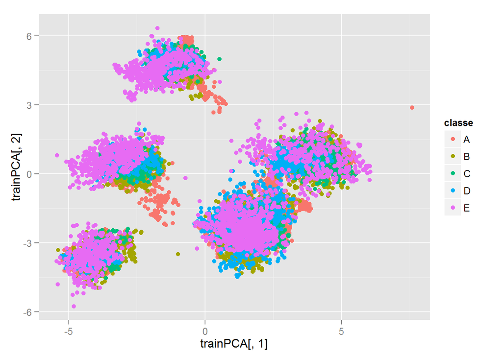

```r
qplot(trainPCA[,1],trainPCA[,2],colour=classe,data=train)
```

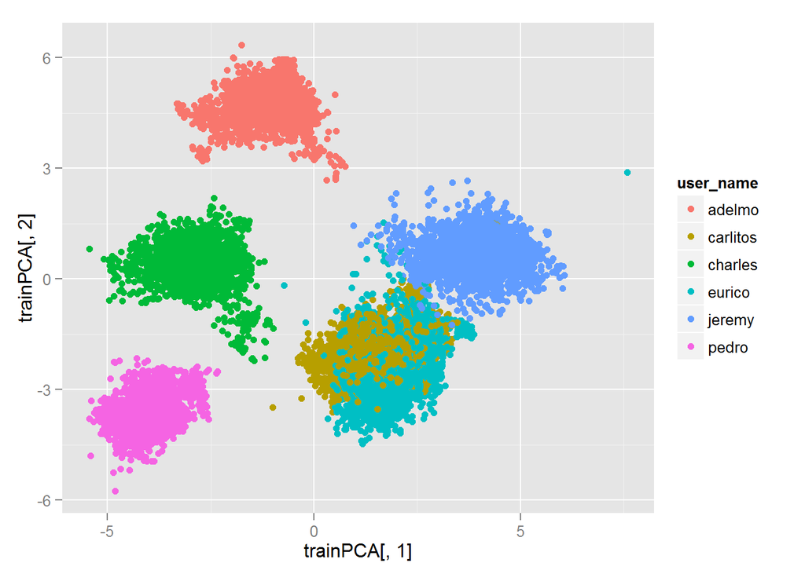

```r
qplot(trainPCA[,1],trainPCA[,2],colour=user_name,data=train)
```

```r
predPCA<-predict(modFitPCA,trainPCA)
comparePCA<-data.frame("orig"=train$classe,"pred"=predPCA)
diffPCA<-comparePCA[comparePCA$orig!=comparePCA$pred,]
dim(diffPCA)
```

```
## [1] 8716    2
```

### Appendix 4 - Cross validation

```r
testPCA<-predict(preProc,test[-c(1,54)])
confusionMatrix(test$classe, predict(modFitPCA,testPCA))
```

```
## Confusion Matrix and Statistics
##
##           Reference
## Prediction   A   B   C   D   E
##          A 882  59 142 164 148
##          B 334 157 139 141 178
##          C 341  56 234 125  99
##          D 196  63  78 263 204
##          E 197  64  97 145 398
##
## Overall Statistics
##
##                Accuracy : 0.3944
##                  95% CI : (0.3807, 0.4082)
##     No Information Rate : 0.3976
##     P-Value [Acc > NIR] : 0.6846
##
##                   Kappa : 0.2237
##  Mcnemar's Test P-Value : <2e-16
##
## Statistics by Class:
##
##                      Class: A Class: B Class: C Class: D Class: E
## Sensitivity            0.4523  0.39348  0.33913  0.31384  0.38754
## Specificity            0.8263  0.82420  0.85263  0.86695  0.87026
## Pos Pred Value         0.6323  0.16544  0.27368  0.32711  0.44173
## Neg Pred Value         0.6956  0.93881  0.88738  0.85976  0.84287
## Prevalence             0.3976  0.08136  0.14070  0.17088  0.20942
## Detection Rate         0.1799  0.03201  0.04772  0.05363  0.08116
## Detection Prevalence   0.2845  0.19352  0.17435  0.16395  0.18373
## Balanced Accuracy      0.6393  0.60884  0.59588  0.59039  0.62890
```

```r
predPCATest<-predict(modFitPCA,testPCA)
comparePCATest<-data.frame("orig"=test$classe,"pred"=predPCATest)
diffPCATest<-comparePCATest[comparePCATest$orig!=comparePCATest$pred,]
dim(diffPCATest)
```

```
## [1] 2970    2
```

### Appendix 5 - Test results

```r
testSmall<-testAll[,-c(1,3:7,12:36,50:59,69:83,87:101, 103:112,125:139,141:150)]
testPCASmall<-predict(preProc,testSmall[-c(1,54)])
answers=predict(modFitPCA,testPCASmall)

pml_write_files = function(x){
  n = length(x)
  for(i in 1:n){
    filename = paste0("problem_id_",i,".txt")
    write.table(x[i],file=filename,quote=FALSE,row.names=FALSE,col.names=FALSE)
  }
}

pml_write_files(answers)

answers
```

```
##  [1] A C A A A C D A A A A C B A A E A D E B
## Levels: A B C D E
```